# MUM 2024-25 Modele generatywne vs dyskryminatywne

Będziemy zawsze pisali $p$, co oznacza:

- prawdopodobieństwo - w przypadku dyskretnym
- wartość funkcji gęstości - w przypadku ciągłym

## Model generatywny

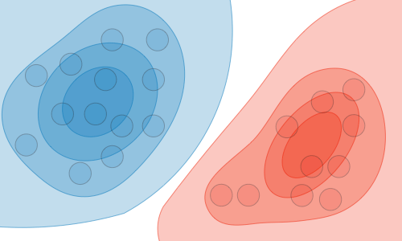

1. uczenie nienadzorowane, *unsupervised learning*
2. dane $$\{\mathbf{x}_n\}$$
   - $\mathbf{x}$ - wektor **przykładów**
     - wartości ciągłe - liczby rzeczywiste
     - wartości dyskretne - np. liczby całkowite
3. rozkład prawdopodobieństwa
   - dane treningowe to **sample (wylosowane próbki) z rozkładu** $p(\mathbf{x})$
   - model uczy się **rozkładu prawdopodobieństwa** $p(\mathbf{x})$
4. generatywność
   - model **nie musi** umieć **generować** (samplować) nowych danych (ale często potrafi)
     - dla generowania danych ze znalezionego rozkładu potrzebne jest spełnienie dodatkowych warunków
   - model **nie musi** umieć podać wartości liczbowej $p(\mathbf{x})$ (ale wtedy powinien umieć przynajmniej samplować)
5. najpopularniejsze modele
   - Variational Auto-Encoder (VAE)
   - Generative Adversarial Networks (GAN)
   - dziesiątki różnych wariantów
6. spektakularne przykłady
   - https://deepmind.com/blog/neural-scene-representation-and-rendering/
   - https://deepmind.com/blog/wavenet-generative-model-raw-audio/
   - https://towardsdatascience.com/auto-regressive-generative-models-pixelrnn-pixelcnn-32d192911173
   - https://affinelayer.com/pixsrv/
   - https://junyanz.github.io/CycleGAN/
   - https://huggingface.co/spaces/stabilityai/stable-diffusion

## Model dyskryminatywny

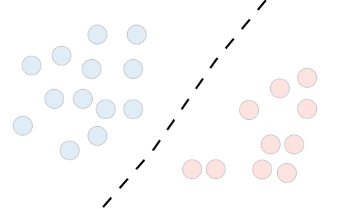

1. uczenie nadzorowane, *supervised learning*
2. dane $$\{(\mathbf{x}_n,y_n)\}$$ lub $$\{(\mathbf{x}_n,\mathbf{y}_n)\}$$
   - $\mathbf{x}$ - wektor **cech**
     - cechy ciągłe - liczby rzeczywiste
     - cechy dyskretne - np. liczby całkowite
   - $y$ - **etykieta**
     - etykieta dyskretna, np. **klasa** w **problemie klasyfikacji**
     - etykieta ciągła, np. liczba rzeczywista w **problemie regresji**
   - $\mathbf{y}$ - **wektor etykiet**
     - **multilabel classification** (nie mylić z klasyfikacją wieloklasową)
     - **multioutput regression**
3. konkretny wektor $\mathbf{x}$ może mieć **wiele różnych "prawdziwych"** wartości $y$
   - np. zdjęcia ręcznie pisanych cyfr - ten sam obrazek może oznaczać $1$ lub $7$
   - "prawdziwa" wartość zależy od osoby, która pisała, nie od obrazka
   - dlatego chcemy $p(y\mid \mathbf{x})$, a nie funkcję $\mathbf{x} \mapsto y$
4. rozkład prawdopodobieństwa
   - dane treningowe to **sample z rozkładu łącznego** $p(\mathbf{x},y)$
   - model uczy się **tylko rozkładu warunkowego** $p(y\mid \mathbf{x})$
   - model **nie** uczy się rozkładu brzegowego $p(\mathbf{x})$ ani rozkładu łącznego $p(\mathbf{x}, y)$
   - ale model może lepiej nauczyć się przewidywać etykiety częstych wartości $\mathbf{x}$, ponieważ jest ich więcej w danych treningowych

## Funkcja dyskryminatywna

1. funkcja **dyskryminatywna**
   - ma za zadanie zwrócić **jedną konkretną wartość** $\widehat{y}$ dla ustalonego $\mathbf{x}$
   - zakładamy, że znamy rozkład $p(y\mid x)$
   - występuje w połączeniu z pewną miarą oceny skuteczności modelu
2. przykład - maksymalizowanie **accuracy** w problemie klasyfikacji $$\widehat{y} = \arg\max_a p(y = a \mid \mathbf{x})$$
   - zawsze wybieramy najbardziej prawdopodobną klasę
   - w ten sposób mylimy się najrzadziej
   - **granica decyzyjna**
     - zbiór $\mathbf{x}$ dla których następuje **zmiana decyzji** $\widehat{y}$
     - w problemie dwuklasowym prawdopodobieństwo wynosi tam 50% / 50%
3. przykład - minimalizowanie **mean squared error** w problemie regresji $$\widehat{y} = \mathbb{E}(y\mid \mathbf{x})$$
   - zawsze wybieramy wartość oczekiwaną pod warunkiem $\mathbf{x}$
   - to optymalizuje błąd średniokwadratowy
   - ale uwaga - inne miary wymagają innego podejścia (co zrobić np. w wypadku **mean absolute error**? dlaczego?)

## Można jeszcze inaczej

- uczenie **częściowo nadzorowane** (*semi-supervised*)
  - połączenie modelu generatywnego i dyskryminatywnego
  - dużo danych **nieetykietowanych**, mało **etykietowanych** (kosztowne etykietowanie)
  - chcemy wykorzystać wszystkie dane
- **klastrowanie** (uczenie nienadzorowane)
  - ekspert może określić klasy dla skupisk

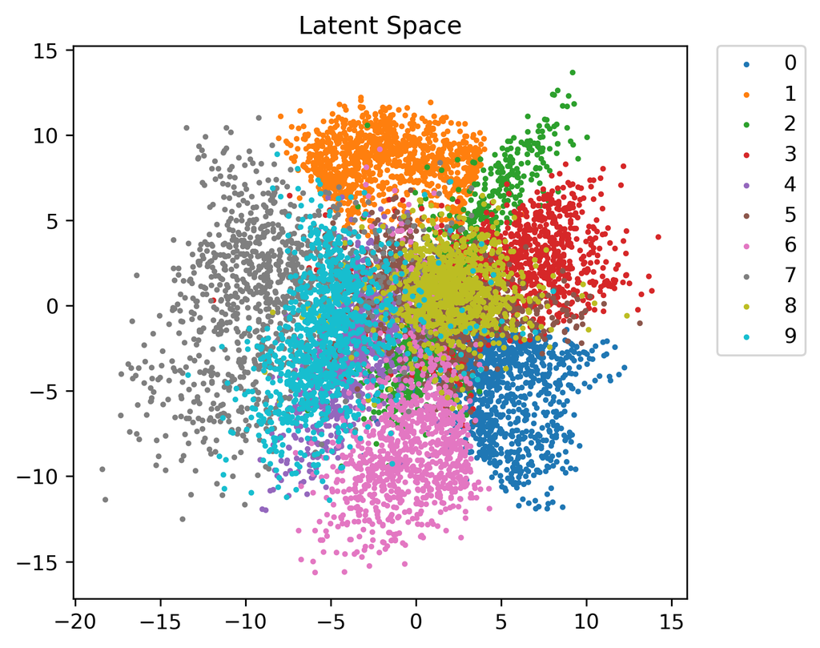

- **uczenie generatywne**
  - model generatywny jak wyżej, a więc modelujący rozkład prawdopodobieństwa danych
  - umiejący jednak generować (samplować, próbkować) przykłady z tego rozkładu
    - prosty przykład modeluje rozkład
    - nie ma jednak generatora losowego z tego rozkładu -- konieczne nałożenie dodatkowych warunków
- agent w **reinforcement learning** (zasada podobna do modeli dyskryminatywnych)
  - robot przewiduje właściwą akcję $y$ na podstawie obserwacji $\mathbf{x}$

## Modele

1. najpopularniejsze modele występują w dwóch wariantach - dla klasyfikacji i dla regresji:
   - naiwny Bayesowski, liniowy, KNN, Support Vector Machines SVM, drzewa decyzyjne i lasy drzew, drzewa gradient boosted, modele składające wyniki, np. AdaBoost
     - to wszystko było
   - **sieci neuronowe**
     - szereg modeli
       - warstwowe, płytkie vs głębokie, problem ufności w rozwiązanie
       - Bayesowskie
       - rekurencyjne dla szeregów czasowych,
       - autoenkodery, autoenkodery generatywne, modele flow,
       - dyfuzyjne
2. modele generatywne to zazwyczaj
   - proste modele gęstościowe
   - głębokie sieci neuronowe